# Risk Factor Analysis

## Outcome Variable

**Outcome Variable:** dead

## Predictor Variables

**Intervention Variable:** ever_co024

**Adjustment Set:**

unadjusted

## Stratifying Variables

The analysis was stratified on these variable(s):

- studyid
- country

## Data Summary

| studyid | country | ever_co024 | dead | n_cell | n |
| --- | --- | --- | --- | --- | --- |
| ki0047075b-MAL-ED | BANGLADESH | 0 | 0 | 222 | 263 |
| ki0047075b-MAL-ED | BANGLADESH | 0 | 1 | 2 | 263 |
| ki0047075b-MAL-ED | BANGLADESH | 1 | 0 | 39 | 263 |
| ki0047075b-MAL-ED | BANGLADESH | 1 | 1 | 0 | 263 |
| ki0047075b-MAL-ED | INDIA | 0 | 0 | 195 | 251 |
| ki0047075b-MAL-ED | INDIA | 0 | 1 | 2 | 251 |
| ki0047075b-MAL-ED | INDIA | 1 | 0 | 54 | 251 |
| ki0047075b-MAL-ED | INDIA | 1 | 1 | 0 | 251 |
| ki0047075b-MAL-ED | PERU | 0 | 0 | 288 | 302 |
| ki0047075b-MAL-ED | PERU | 0 | 1 | 2 | 302 |
| ki0047075b-MAL-ED | PERU | 1 | 0 | 12 | 302 |
| ki0047075b-MAL-ED | PERU | 1 | 1 | 0 | 302 |
| ki0047075b-MAL-ED | SOUTH AFRICA | 0 | 0 | 290 | 312 |
| ki0047075b-MAL-ED | SOUTH AFRICA | 0 | 1 | 0 | 312 |
| ki0047075b-MAL-ED | SOUTH AFRICA | 1 | 0 | 22 | 312 |
| ki0047075b-MAL-ED | SOUTH AFRICA | 1 | 1 | 0 | 312 |
| ki0047075b-MAL-ED | TANZANIA, UNITED REPUBLIC OF | 0 | 0 | 235 | 261 |
| ki0047075b-MAL-ED | TANZANIA, UNITED REPUBLIC OF | 0 | 1 | 3 | 261 |
| ki0047075b-MAL-ED | TANZANIA, UNITED REPUBLIC OF | 1 | 0 | 23 | 261 |
| ki0047075b-MAL-ED | TANZANIA, UNITED REPUBLIC OF | 1 | 1 | 0 | 261 |
| ki1000304-VITAMIN-A | INDIA | 0 | 0 | 3171 | 3802 |
| ki1000304-VITAMIN-A | INDIA | 0 | 1 | 42 | 3802 |
| ki1000304-VITAMIN-A | INDIA | 1 | 0 | 573 | 3802 |
| ki1000304-VITAMIN-A | INDIA | 1 | 1 | 16 | 3802 |
| ki1000304b-SAS-CompFeed | INDIA | 0 | 0 | 1139 | 1513 |
| ki1000304b-SAS-CompFeed | INDIA | 0 | 1 | 22 | 1513 |
| ki1000304b-SAS-CompFeed | INDIA | 1 | 0 | 337 | 1513 |
| ki1000304b-SAS-CompFeed | INDIA | 1 | 1 | 15 | 1513 |
| ki1000304b-SAS-FoodSuppl | INDIA | 0 | 0 | 259 | 418 |
| ki1000304b-SAS-FoodSuppl | INDIA | 0 | 1 | 3 | 418 |
| ki1000304b-SAS-FoodSuppl | INDIA | 1 | 0 | 153 | 418 |
| ki1000304b-SAS-FoodSuppl | INDIA | 1 | 1 | 3 | 418 |
| ki1017093b-PROVIDE | BANGLADESH | 0 | 0 | 605 | 699 |
| ki1017093b-PROVIDE | BANGLADESH | 0 | 1 | 4 | 699 |
| ki1017093b-PROVIDE | BANGLADESH | 1 | 0 | 90 | 699 |
| ki1017093b-PROVIDE | BANGLADESH | 1 | 1 | 0 | 699 |
| ki1066203-TanzaniaChild2 | TANZANIA, UNITED REPUBLIC OF | 0 | 0 | 2276 | 2396 |
| ki1066203-TanzaniaChild2 | TANZANIA, UNITED REPUBLIC OF | 0 | 1 | 1 | 2396 |
| ki1066203-TanzaniaChild2 | TANZANIA, UNITED REPUBLIC OF | 1 | 0 | 119 | 2396 |
| ki1066203-TanzaniaChild2 | TANZANIA, UNITED REPUBLIC OF | 1 | 1 | 0 | 2396 |
| ki1101329-Keneba | GAMBIA | 0 | 0 | 2412 | 2877 |
| ki1101329-Keneba | GAMBIA | 0 | 1 | 46 | 2877 |
| ki1101329-Keneba | GAMBIA | 1 | 0 | 403 | 2877 |
| ki1101329-Keneba | GAMBIA | 1 | 1 | 16 | 2877 |
| ki1112895-Burkina Faso Zn | BURKINA FASO | 0 | 0 | 6310 | 7154 |
| ki1112895-Burkina Faso Zn | BURKINA FASO | 0 | 1 | 31 | 7154 |
| ki1112895-Burkina Faso Zn | BURKINA FASO | 1 | 0 | 805 | 7154 |
| ki1112895-Burkina Faso Zn | BURKINA FASO | 1 | 1 | 8 | 7154 |
| ki1113344-GMS-Nepal | NEPAL | 0 | 0 | 405 | 602 |
| ki1113344-GMS-Nepal | NEPAL | 0 | 1 | 4 | 602 |
| ki1113344-GMS-Nepal | NEPAL | 1 | 0 | 192 | 602 |
| ki1113344-GMS-Nepal | NEPAL | 1 | 1 | 1 | 602 |
| ki1126311-ZVITAMBO | ZIMBABWE | 0 | 0 | 12424 | 13913 |
| ki1126311-ZVITAMBO | ZIMBABWE | 0 | 1 | 895 | 13913 |
| ki1126311-ZVITAMBO | ZIMBABWE | 1 | 0 | 453 | 13913 |
| ki1126311-ZVITAMBO | ZIMBABWE | 1 | 1 | 141 | 13913 |
| ki1148112-iLiNS-DOSE | MALAWI | 0 | 0 | 1708 | 1854 |
| ki1148112-iLiNS-DOSE | MALAWI | 0 | 1 | 45 | 1854 |
| ki1148112-iLiNS-DOSE | MALAWI | 1 | 0 | 95 | 1854 |
| ki1148112-iLiNS-DOSE | MALAWI | 1 | 1 | 6 | 1854 |
| ki1148112-iLiNS-DYAD-M | MALAWI | 0 | 0 | 1112 | 1195 |
| ki1148112-iLiNS-DYAD-M | MALAWI | 0 | 1 | 30 | 1195 |
| ki1148112-iLiNS-DYAD-M | MALAWI | 1 | 0 | 48 | 1195 |
| ki1148112-iLiNS-DYAD-M | MALAWI | 1 | 1 | 5 | 1195 |
| kiGH5241-JiVitA-3 | BANGLADESH | 0 | 0 | 24026 | 26878 |
| kiGH5241-JiVitA-3 | BANGLADESH | 0 | 1 | 453 | 26878 |
| kiGH5241-JiVitA-3 | BANGLADESH | 1 | 0 | 2307 | 26878 |
| kiGH5241-JiVitA-3 | BANGLADESH | 1 | 1 | 92 | 26878 |
| kiGH5241-JiVitA-4 | BANGLADESH | 0 | 0 | 4525 | 5433 |
| kiGH5241-JiVitA-4 | BANGLADESH | 0 | 1 | 32 | 5433 |
| kiGH5241-JiVitA-4 | BANGLADESH | 1 | 0 | 867 | 5433 |
| kiGH5241-JiVitA-4 | BANGLADESH | 1 | 1 | 9 | 5433 |

The following strata were considered:

- studyid: ki0047075b-MAL-ED, country: BANGLADESH
- studyid: ki0047075b-MAL-ED, country: INDIA
- studyid: ki0047075b-MAL-ED, country: PERU
- studyid: ki0047075b-MAL-ED, country: SOUTH AFRICA
- studyid: ki0047075b-MAL-ED, country: TANZANIA, UNITED REPUBLIC OF
- studyid: ki1000304-VITAMIN-A, country: INDIA
- studyid: ki1000304b-SAS-CompFeed, country: INDIA
- studyid: ki1000304b-SAS-FoodSuppl, country: INDIA
- studyid: ki1017093b-PROVIDE, country: BANGLADESH
- studyid: ki1066203-TanzaniaChild2, country: TANZANIA, UNITED REPUBLIC OF
- studyid: ki1101329-Keneba, country: GAMBIA
- studyid: ki1112895-Burkina Faso Zn, country: BURKINA FASO
- studyid: ki1113344-GMS-Nepal, country: NEPAL
- studyid: ki1126311-ZVITAMBO, country: ZIMBABWE
- studyid: ki1148112-iLiNS-DOSE, country: MALAWI
- studyid: ki1148112-iLiNS-DYAD-M, country: MALAWI
- studyid: kiGH5241-JiVitA-3, country: BANGLADESH
- studyid: kiGH5241-JiVitA-4, country: BANGLADESH

### Dropped Strata

Some strata were dropped due to rare outcomes:

- studyid: ki0047075b-MAL-ED, country: BANGLADESH
- studyid: ki0047075b-MAL-ED, country: INDIA
- studyid: ki0047075b-MAL-ED, country: PERU
- studyid: ki0047075b-MAL-ED, country: SOUTH AFRICA
- studyid: ki0047075b-MAL-ED, country: TANZANIA, UNITED REPUBLIC OF
- studyid: ki1000304b-SAS-FoodSuppl, country: INDIA
- studyid: ki1017093b-PROVIDE, country: BANGLADESH
- studyid: ki1066203-TanzaniaChild2, country: TANZANIA, UNITED REPUBLIC OF
- studyid: ki1113344-GMS-Nepal, country: NEPAL

## Methods Detail

We’re interested in the causal parameters $E[Y_a]$ for all values of $a \in \mathcal{A}$. These parameters represent the mean outcome if, possibly contrary to fact, we intervened to set all units to have $A=a$. Under the randomization and positivity assumptions, these are identified by the statistical parameters $\psi_a=E_W[E_{Y|A,W}(Y|A=a,W)]$. In addition, we’re interested in the mean of $Y$, $E[Y]$ under no intervention (the observed mean). We will estimate these parameters by using SuperLearner to fit the relevant likelihood factors – $E_{Y|A,W}(Y|A=a,W)$ and $p(A=a|W)$, and then updating our likelihood fit using a joint TMLE.

For unadjusted analyses ($W=\{\}$), initial likelihoods were estimated using Lrnr_glm to estimate the simple $E(Y|A)$ and Lrnr_mean to estimate $p(A)$. For adjusted analyses, a small library containing Lrnr_glmnet, Lrnr_xgboost, and Lrnr_mean was used.

Having estimated these parameters, we will then use the delta method to estimate relative risks and attributable risks relative to a prespecified baseline level of $A$.

# Results Detail

## Results Plots

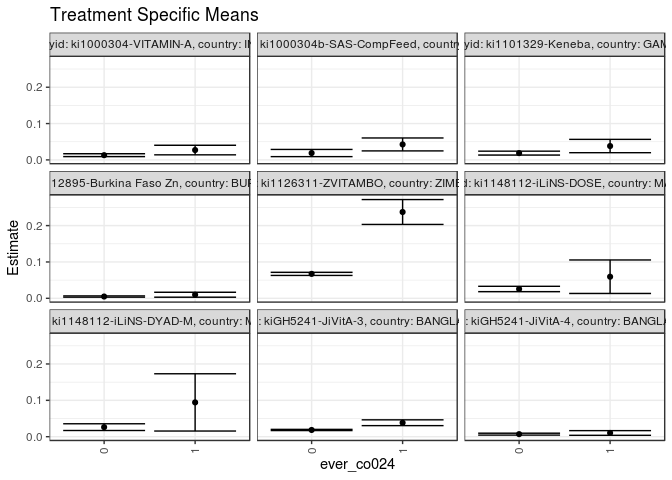

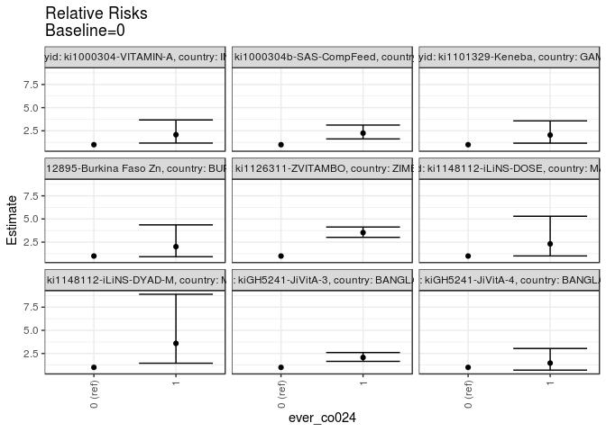

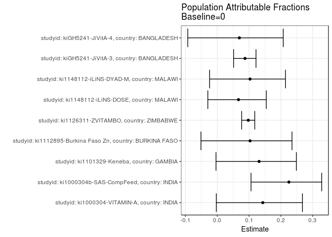

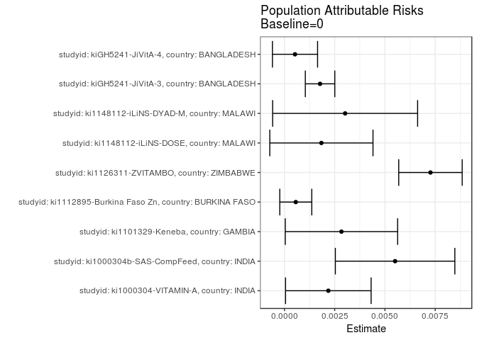

## Results Table

### Parameter: TSM

| studyid | country | intervention_level | baseline_level | estimate | ci_lower | ci_upper |
| --- | --- | --- | --- | --- | --- | --- |
| ki1000304-VITAMIN-A | INDIA | 0 | NA | 0.0130719 | 0.0091440 | 0.0169998 |
| ki1000304-VITAMIN-A | INDIA | 1 | NA | 0.0271647 | 0.0140345 | 0.0402948 |
| ki1000304b-SAS-CompFeed | INDIA | 0 | NA | 0.0189492 | 0.0090769 | 0.0288215 |
| ki1000304b-SAS-CompFeed | INDIA | 1 | NA | 0.0426136 | 0.0248624 | 0.0603649 |
| ki1101329-Keneba | GAMBIA | 0 | NA | 0.0187144 | 0.0133562 | 0.0240726 |
| ki1101329-Keneba | GAMBIA | 1 | NA | 0.0381862 | 0.0198328 | 0.0565395 |
| ki1112895-Burkina Faso Zn | BURKINA FASO | 0 | NA | 0.0048888 | 0.0031719 | 0.0066057 |
| ki1112895-Burkina Faso Zn | BURKINA FASO | 1 | NA | 0.0098401 | 0.0030545 | 0.0166257 |
| ki1126311-ZVITAMBO | ZIMBABWE | 0 | NA | 0.0671972 | 0.0629452 | 0.0714493 |
| ki1126311-ZVITAMBO | ZIMBABWE | 1 | NA | 0.2373737 | 0.2031567 | 0.2715908 |
| ki1148112-iLiNS-DOSE | MALAWI | 0 | NA | 0.0256703 | 0.0182650 | 0.0330756 |
| ki1148112-iLiNS-DOSE | MALAWI | 1 | NA | 0.0594059 | 0.0132932 | 0.1055186 |
| ki1148112-iLiNS-DYAD-M | MALAWI | 0 | NA | 0.0262697 | 0.0169821 | 0.0355573 |
| ki1148112-iLiNS-DYAD-M | MALAWI | 1 | NA | 0.0943396 | 0.0155470 | 0.1731322 |
| kiGH5241-JiVitA-3 | BANGLADESH | 0 | NA | 0.0185057 | 0.0168067 | 0.0202046 |
| kiGH5241-JiVitA-3 | BANGLADESH | 1 | NA | 0.0383493 | 0.0303806 | 0.0463180 |
| kiGH5241-JiVitA-4 | BANGLADESH | 0 | NA | 0.0070222 | 0.0044157 | 0.0096286 |
| kiGH5241-JiVitA-4 | BANGLADESH | 1 | NA | 0.0102740 | 0.0038233 | 0.0167247 |

### Parameter: E(Y)

| studyid | country | intervention_level | baseline_level | estimate | ci_lower | ci_upper |
| --- | --- | --- | --- | --- | --- | --- |
| ki1000304-VITAMIN-A | INDIA | NA | NA | 0.0152551 | 0.0113587 | 0.0191516 |
| ki1000304b-SAS-CompFeed | INDIA | NA | NA | 0.0244547 | 0.0133604 | 0.0355490 |
| ki1101329-Keneba | GAMBIA | NA | NA | 0.0215502 | 0.0162432 | 0.0268572 |
| ki1112895-Burkina Faso Zn | BURKINA FASO | NA | NA | 0.0054515 | 0.0037451 | 0.0071579 |
| ki1126311-ZVITAMBO | ZIMBABWE | NA | NA | 0.0744627 | 0.0701004 | 0.0788251 |
| ki1148112-iLiNS-DOSE | MALAWI | NA | NA | 0.0275081 | 0.0200611 | 0.0349551 |
| ki1148112-iLiNS-DYAD-M | MALAWI | NA | NA | 0.0292887 | 0.0197168 | 0.0388606 |
| kiGH5241-JiVitA-3 | BANGLADESH | NA | NA | 0.0202768 | 0.0185700 | 0.0219836 |
| kiGH5241-JiVitA-4 | BANGLADESH | NA | NA | 0.0075465 | 0.0051309 | 0.0099620 |

### Parameter: RR

| studyid | country | intervention_level | baseline_level | estimate | ci_lower | ci_upper |
| --- | --- | --- | --- | --- | --- | --- |
| ki1000304-VITAMIN-A | INDIA | 0 | 0 | 1.000000 | 1.0000000 | 1.000000 |
| ki1000304-VITAMIN-A | INDIA | 1 | 0 | 2.078098 | 1.1762269 | 3.671480 |
| ki1000304b-SAS-CompFeed | INDIA | 0 | 0 | 1.000000 | 1.0000000 | 1.000000 |
| ki1000304b-SAS-CompFeed | INDIA | 1 | 0 | 2.248838 | 1.6204533 | 3.120899 |
| ki1101329-Keneba | GAMBIA | 0 | 0 | 1.000000 | 1.0000000 | 1.000000 |
| ki1101329-Keneba | GAMBIA | 1 | 0 | 2.040469 | 1.1661812 | 3.570212 |
| ki1112895-Burkina Faso Zn | BURKINA FASO | 0 | 0 | 1.000000 | 1.0000000 | 1.000000 |
| ki1112895-Burkina Faso Zn | BURKINA FASO | 1 | 0 | 2.012776 | 0.9283550 | 4.363922 |
| ki1126311-ZVITAMBO | ZIMBABWE | 0 | 0 | 1.000000 | 1.0000000 | 1.000000 |
| ki1126311-ZVITAMBO | ZIMBABWE | 1 | 0 | 3.532493 | 3.0179514 | 4.134760 |
| ki1148112-iLiNS-DOSE | MALAWI | 0 | 0 | 1.000000 | 1.0000000 | 1.000000 |
| ki1148112-iLiNS-DOSE | MALAWI | 1 | 0 | 2.314191 | 1.0110185 | 5.297116 |
| ki1148112-iLiNS-DYAD-M | MALAWI | 0 | 0 | 1.000000 | 1.0000000 | 1.000000 |
| ki1148112-iLiNS-DYAD-M | MALAWI | 1 | 0 | 3.591195 | 1.4499595 | 8.894511 |
| kiGH5241-JiVitA-3 | BANGLADESH | 0 | 0 | 1.000000 | 1.0000000 | 1.000000 |
| kiGH5241-JiVitA-3 | BANGLADESH | 1 | 0 | 2.072302 | 1.6501211 | 2.602497 |
| kiGH5241-JiVitA-4 | BANGLADESH | 0 | 0 | 1.000000 | 1.0000000 | 1.000000 |
| kiGH5241-JiVitA-4 | BANGLADESH | 1 | 0 | 1.463078 | 0.7040608 | 3.040358 |

### Parameter: PAR

| studyid | country | intervention_level | baseline_level | estimate | ci_lower | ci_upper |
| --- | --- | --- | --- | --- | --- | --- |
| ki1000304-VITAMIN-A | INDIA | 0 | NA | 0.0021832 | 0.0000539 | 0.0043126 |
| ki1000304b-SAS-CompFeed | INDIA | 0 | NA | 0.0055055 | 0.0025324 | 0.0084787 |
| ki1101329-Keneba | GAMBIA | 0 | NA | 0.0028358 | 0.0000400 | 0.0056316 |
| ki1112895-Burkina Faso Zn | BURKINA FASO | 0 | NA | 0.0005627 | -0.0002336 | 0.0013589 |
| ki1126311-ZVITAMBO | ZIMBABWE | 0 | NA | 0.0072655 | 0.0056863 | 0.0088447 |
| ki1148112-iLiNS-DOSE | MALAWI | 0 | NA | 0.0018378 | -0.0007302 | 0.0044058 |
| ki1148112-iLiNS-DYAD-M | MALAWI | 0 | NA | 0.0030190 | -0.0005886 | 0.0066266 |
| kiGH5241-JiVitA-3 | BANGLADESH | 0 | NA | 0.0017711 | 0.0010379 | 0.0025044 |
| kiGH5241-JiVitA-4 | BANGLADESH | 0 | NA | 0.0005243 | -0.0005994 | 0.0016481 |

### Parameter: PAF

| studyid | country | intervention_level | baseline_level | estimate | ci_lower | ci_upper |
| --- | --- | --- | --- | --- | --- | --- |
| ki1000304-VITAMIN-A | INDIA | 0 | NA | 0.1431147 | -0.0029168 | 0.2678830 |
| ki1000304b-SAS-CompFeed | INDIA | 0 | NA | 0.2251321 | 0.1062099 | 0.3282313 |
| ki1101329-Keneba | GAMBIA | 0 | NA | 0.1315914 | -0.0037562 | 0.2486886 |
| ki1112895-Burkina Faso Zn | BURKINA FASO | 0 | NA | 0.1032151 | -0.0512090 | 0.2349541 |
| ki1126311-ZVITAMBO | ZIMBABWE | 0 | NA | 0.0975722 | 0.0767977 | 0.1178793 |
| ki1148112-iLiNS-DOSE | MALAWI | 0 | NA | 0.0668098 | -0.0295258 | 0.1541311 |
| ki1148112-iLiNS-DYAD-M | MALAWI | 0 | NA | 0.1030773 | -0.0238760 | 0.2142893 |
| kiGH5241-JiVitA-3 | BANGLADESH | 0 | NA | 0.0873485 | 0.0514180 | 0.1219180 |
| kiGH5241-JiVitA-4 | BANGLADESH | 0 | NA | 0.0694777 | -0.0924980 | 0.2074385 |